# MUJIDAT Loan Default analysis-Corrected 2

MUJIDAT FADEYI- LOAN DEFAULT ANALYSIS

Business Problem Title: Credit Risk Scoring for Underbanked Populations

Decisions to be Made: Approve or reject the loan application Predict whether the loan will be good (1) or bad (0)

What interest rate or limits should apply? Set the interest rate based on predicted default risk Determine the maximum loan amount (credit limit) for the customer Define the loan term length (termdays) based on risk profile

Business Objectives: Reduce loan default rate Improve credit risk prediction accuracy Maximize portfolio profitability Enable responsible and data-driven lending decisions

```python
#IMPORTING LIBRARIES

import numpy as np
import pandas as pd

import matplotlib.pyplot as plt
import seaborn as sns
%matplotlib inline
```

```python
#Load datasets

demographics = pd.read_csv('C:\\Users\\MY PC\\Downloads\data-science-nigeria-credit-risk-prediction\\traindemographics.csv')
performance = pd.read_csv('C:\\Users\\MY PC\\Downloads\\data-science-nigeria-credit-risk-prediction\\trainperf.csv')
previous_loans = pd.read_csv('C:\\Users\\MY PC\\Downloads\\data-science-nigeria-credit-risk-prediction\\trainprevloans.csv')
```

```python
demographics.head()
```

|  | customerid | birthdate | bank_account_type | longitude_gps | latitude_gps | bank_name_clients | bank_branch_clients | employment_status_clients | level_of_education_clients |
| --- | --- | --- | --- | --- | --- | --- | --- | --- | --- |
| 0 | 8a858e135cb22031015cbafc76964ebd | 1973-10-10 00:00:00.000000 | Savings | 3.319219 | 6.528604 | GT Bank | NaN | NaN | NaN |
| 1 | 8a858e275c7ea5ec015c82482d7c3996 | 1986-01-21 00:00:00.000000 | Savings | 3.325598 | 7.119403 | Sterling Bank | NaN | Permanent | NaN |
| 2 | 8a858e5b5bd99460015bdc95cd485634 | 1987-04-01 00:00:00.000000 | Savings | 5.746100 | 5.563174 | Fidelity Bank | NaN | NaN | NaN |
| 3 | 8a858efd5ca70688015cabd1f1e94b55 | 1991-07-19 00:00:00.000000 | Savings | 3.362850 | 6.642485 | GT Bank | NaN | Permanent | NaN |
| 4 | 8a858e785acd3412015acd48f4920d04 | 1982-11-22 00:00:00.000000 | Savings | 8.455332 | 11.971410 | GT Bank | NaN | Permanent | NaN |

```python
performance.head()
```

|  | customerid | systemloanid | loannumber | approveddate | creationdate | loanamount | totaldue | termdays | referredby | good_bad_flag |
| --- | --- | --- | --- | --- | --- | --- | --- | --- | --- | --- |
| 0 | 8a2a81a74ce8c05d014cfb32a0da1049 | 301994762 | 12 | 2017-07-25 08:22:56.000000 | 2017-07-25 07:22:47.000000 | 30000.0 | 34500.0 | 30 | NaN | Good |
| 1 | 8a85886e54beabf90154c0a29ae757c0 | 301965204 | 2 | 2017-07-05 17:04:41.000000 | 2017-07-05 16:04:18.000000 | 15000.0 | 17250.0 | 30 | NaN | Good |
| 2 | 8a8588f35438fe12015444567666018e | 301966580 | 7 | 2017-07-06 14:52:57.000000 | 2017-07-06 13:52:51.000000 | 20000.0 | 22250.0 | 15 | NaN | Good |
| 3 | 8a85890754145ace015429211b513e16 | 301999343 | 3 | 2017-07-27 19:00:41.000000 | 2017-07-27 18:00:35.000000 | 10000.0 | 11500.0 | 15 | NaN | Good |
| 4 | 8a858970548359cc0154883481981866 | 301962360 | 9 | 2017-07-03 23:42:45.000000 | 2017-07-03 22:42:39.000000 | 40000.0 | 44000.0 | 30 | NaN | Good |

```python
previous_loans.head()
```

|  | customerid | systemloanid | loannumber | approveddate | creationdate | loanamount | totaldue | termdays | closeddate | referredby | firstduedate | firstrepaiddate |
| --- | --- | --- | --- | --- | --- | --- | --- | --- | --- | --- | --- | --- |
| 0 | 8a2a81a74ce8c05d014cfb32a0da1049 | 301682320 | 2 | 2016-08-15 18:22:40.000000 | 2016-08-15 17:22:32.000000 | 10000.0 | 13000.0 | 30 | 2016-09-01 16:06:48.000000 | NaN | 2016-09-14 00:00:00.000000 | 2016-09-01 15:51:43.000000 |
| 1 | 8a2a81a74ce8c05d014cfb32a0da1049 | 301883808 | 9 | 2017-04-28 18:39:07.000000 | 2017-04-28 17:38:53.000000 | 10000.0 | 13000.0 | 30 | 2017-05-28 14:44:49.000000 | NaN | 2017-05-30 00:00:00.000000 | 2017-05-26 00:00:00.000000 |
| 2 | 8a2a81a74ce8c05d014cfb32a0da1049 | 301831714 | 8 | 2017-03-05 10:56:25.000000 | 2017-03-05 09:56:19.000000 | 20000.0 | 23800.0 | 30 | 2017-04-26 22:18:56.000000 | NaN | 2017-04-04 00:00:00.000000 | 2017-04-26 22:03:47.000000 |
| 3 | 8a8588f35438fe12015444567666018e | 301861541 | 5 | 2017-04-09 18:25:55.000000 | 2017-04-09 17:25:42.000000 | 10000.0 | 11500.0 | 15 | 2017-04-24 01:35:52.000000 | NaN | 2017-04-24 00:00:00.000000 | 2017-04-24 00:48:43.000000 |
| 4 | 8a85890754145ace015429211b513e16 | 301941754 | 2 | 2017-06-17 09:29:57.000000 | 2017-06-17 08:29:50.000000 | 10000.0 | 11500.0 | 15 | 2017-07-14 21:18:43.000000 | NaN | 2017-07-03 00:00:00.000000 | 2017-07-14 21:08:35.000000 |

```python
demographics.info()
```

[output not shown]

```python
performance.info()
```

```
<class 'pandas.core.frame.DataFrame'>
RangeIndex: 4368 entries, 0 to 4367
Data columns (total 10 columns):
 #   Column         Non-Null Count  Dtype
---  ------         --------------  -----
 0   customerid     4368 non-null   object
 1   systemloanid   4368 non-null   int64
 2   loannumber     4368 non-null   int64
 3   approveddate   4368 non-null   datetime64[ns]
 4   creationdate   4368 non-null   object
 5   loanamount     4368 non-null   float64
 6   totaldue       4368 non-null   float64
 7   termdays       4368 non-null   int64
 8   referredby     587 non-null    object
 9   good_bad_flag  4368 non-null   object
dtypes: datetime64[ns](1), float64(2), int64(3), object(4)
memory usage: 341.4+ KB
```

```python
previous_loans.info()
```

[output not shown]

```python
#Convert date columns

demographics['birthdate'] = pd.to_datetime(demographics['birthdate'])
performance['approveddate'] = pd.to_datetime(performance['approveddate'])
previous_loans['approveddate'] = pd.to_datetime(previous_loans['approveddate'])
previous_loans['firstrepaiddate'] = pd.to_datetime(previous_loans['firstrepaiddate'])
```

```python
#Creating Age feature

today = pd.to_datetime('today')
demographics['age'] = (today - demographics['birthdate']).dt.days // 365
```

```python
demographics.head()
```

|  | customerid | birthdate | bank_account_type | longitude_gps | latitude_gps | bank_name_clients | bank_branch_clients | employment_status_clients | level_of_education_clients | age |
| --- | --- | --- | --- | --- | --- | --- | --- | --- | --- | --- |
| 0 | 8a858e135cb22031015cbafc76964ebd | 1973-10-10 | Savings | 3.319219 | 6.528604 | GT Bank | NaN | NaN | NaN | 52 |
| 1 | 8a858e275c7ea5ec015c82482d7c3996 | 1986-01-21 | Savings | 3.325598 | 7.119403 | Sterling Bank | NaN | Permanent | NaN | 40 |
| 2 | 8a858e5b5bd99460015bdc95cd485634 | 1987-04-01 | Savings | 5.746100 | 5.563174 | Fidelity Bank | NaN | NaN | NaN | 39 |
| 3 | 8a858efd5ca70688015cabd1f1e94b55 | 1991-07-19 | Savings | 3.362850 | 6.642485 | GT Bank | NaN | Permanent | NaN | 34 |
| 4 | 8a858e785acd3412015acd48f4920d04 | 1982-11-22 | Savings | 8.455332 | 11.971410 | GT Bank | NaN | Permanent | NaN | 43 |

```python
#Create previous loan feature

previous_loans['days_to_first_payment'] = (
    previous_loans['firstrepaiddate'] - previous_loans['approveddate']
).dt.days
```

```python
#create repayment delay feature

previous_loans['days_to_first_payment'] = (
    previous_loans['firstrepaiddate'] - previous_loans['approveddate']
).dt.days
```

```python
#aggregated previous loan per customer

prev_agg = previous_loans.groupby('customerid').agg({
    'systemloanid': 'count',
    'loanamount': 'mean',
    'days_to_first_payment': 'mean'
}).reset_index()

prev_agg.columns = [
    'customerid',
    'num_prev_loans',
    'avg_prev_loan_amount',
    'avg_days_to_first_payment'
]
```

```python
#merging demographics and performance dataset +

data = pd.merge(performance, demographics, on='customerid', how='left')
```

```python
data.head()
```

|  | customerid | systemloanid | loannumber | approveddate | creationdate | loanamount | totaldue | termdays | referredby | good_bad_flag | birthdate | bank_account_type | longitude_gps | latitude_gps | bank_name_clients | bank_branch_clients | employment_status_clients | level_of_education_clients | age |
| --- | --- | --- | --- | --- | --- | --- | --- | --- | --- | --- | --- | --- | --- | --- | --- | --- | --- | --- | --- |
| 0 | 8a2a81a74ce8c05d014cfb32a0da1049 | 301994762 | 12 | 2017-07-25 08:22:56 | 2017-07-25 07:22:47.000000 | 30000.0 | 34500.0 | 30 | NaN | Good | 1972-01-15 | Other | 3.432010 | 6.433055 | Diamond Bank | NaN | Permanent | Post-Graduate | 54.0 |
| 1 | 8a85886e54beabf90154c0a29ae757c0 | 301965204 | 2 | 2017-07-05 17:04:41 | 2017-07-05 16:04:18.000000 | 15000.0 | 17250.0 | 30 | NaN | Good | 1985-08-23 | Savings | 3.885298 | 7.320700 | GT Bank | DUGBE,IBADAN | Permanent | Graduate | 40.0 |
| 2 | 8a8588f35438fe12015444567666018e | 301966580 | 7 | 2017-07-06 14:52:57 | 2017-07-06 13:52:51.000000 | 20000.0 | 22250.0 | 15 | NaN | Good | 1984-09-18 | Other | 11.139350 | 10.292041 | EcoBank | NaN | Permanent | NaN | 41.0 |
| 3 | 8a85890754145ace015429211b513e16 | 301999343 | 3 | 2017-07-27 19:00:41 | 2017-07-27 18:00:35.000000 | 10000.0 | 11500.0 | 15 | NaN | Good | 1977-10-10 | Savings | 3.985770 | 7.491708 | First Bank | NaN | Permanent | NaN | 48.0 |
| 4 | 8a858970548359cc0154883481981866 | 301962360 | 9 | 2017-07-03 23:42:45 | 2017-07-03 22:42:39.000000 | 40000.0 | 44000.0 | 30 | NaN | Good | 1986-09-07 | Other | 7.457913 | 9.076574 | GT Bank | NaN | Permanent | Primary | 39.0 |

```python
#Join aggregated previous loan data with merged dataset

data = pd.merge(data, prev_agg, on='customerid', how='left')
```

```python
#first five rows of merged dataset

data.head()
```

|  | customerid | systemloanid | loannumber | approveddate | creationdate | loanamount | totaldue | termdays | referredby | good_bad_flag | ... | longitude_gps | latitude_gps | bank_name_clients | bank_branch_clients | employment_status_clients | level_of_education_clients | age | num_prev_loans | avg_prev_loan_amount | avg_days_to_first_payment |
| --- | --- | --- | --- | --- | --- | --- | --- | --- | --- | --- | --- | --- | --- | --- | --- | --- | --- | --- | --- | --- | --- |
| 0 | 8a2a81a74ce8c05d014cfb32a0da1049 | 301994762 | 12 | 2017-07-25 08:22:56 | 2017-07-25 07:22:47.000000 | 30000.0 | 34500.0 | 30 | NaN | Good | ... | 3.432010 | 6.433055 | Diamond Bank | NaN | Permanent | Post-Graduate | 54.0 | 11.0 | 18181.818182 | 29.272727 |
| 1 | 8a85886e54beabf90154c0a29ae757c0 | 301965204 | 2 | 2017-07-05 17:04:41 | 2017-07-05 16:04:18.000000 | 15000.0 | 17250.0 | 30 | NaN | Good | ... | 3.885298 | 7.320700 | GT Bank | DUGBE,IBADAN | Permanent | Graduate | 40.0 | NaN | NaN | NaN |
| 2 | 8a8588f35438fe12015444567666018e | 301966580 | 7 | 2017-07-06 14:52:57 | 2017-07-06 13:52:51.000000 | 20000.0 | 22250.0 | 15 | NaN | Good | ... | 11.139350 | 10.292041 | EcoBank | NaN | Permanent | NaN | 41.0 | 6.0 | 10000.000000 | 18.166667 |
| 3 | 8a85890754145ace015429211b513e16 | 301999343 | 3 | 2017-07-27 19:00:41 | 2017-07-27 18:00:35.000000 | 10000.0 | 11500.0 | 15 | NaN | Good | ... | 3.985770 | 7.491708 | First Bank | NaN | Permanent | NaN | 48.0 | 2.0 | 10000.000000 | 31.500000 |
| 4 | 8a858970548359cc0154883481981866 | 301962360 | 9 | 2017-07-03 23:42:45 | 2017-07-03 22:42:39.000000 | 40000.0 | 44000.0 | 30 | NaN | Good | ... | 7.457913 | 9.076574 | GT Bank | NaN | Permanent | Primary | 39.0 | 8.0 | 18750.000000 | 26.875000 |

5 rows × 22 columns

```python
#checking for number of duplicates in demographics dataset

demographics.duplicated().sum()
```

```
np.int64(12)
```

it has 12 duplicates

```python
performance.duplicated().sum()
```

```
np.int64(0)
```

```python
previous_loans.duplicated().sum()
```

```
np.int64(0)
```

```python
#to check for missing values after merging the dataset

print(data.isnull().sum())
```

[output not shown]

```python
 #fill missing values

data.fillna({
    'num_prev_loans': 0,
    'avg_prev_loan_amount': 0,
    'prev_default_rate': 0,
    'avg_days_to_first_payment': 0
}, inplace=True)
```

FEATURE ENGINEERING

```python
#create loan metric

data['loan_to_due_ratio'] = data['loanamount'] / data['totaldue']
```

```python
import pandas as pd
```

```python
#encoding categorical column to numerical column using one hot encoding

categorical_cols = ['employment_status_clients', 'education_level_clients']
categorical_cols  = pd.get_dummies(data, columns= ['employment_status_clients', 'level_of_education_clients'], dtype = int)
categorical_cols
```

|  | customerid | systemloanid | loannumber | approveddate | creationdate | loanamount | totaldue | termdays | referredby | good_bad_flag | ... | employment_status_clients_Contract | employment_status_clients_Permanent | employment_status_clients_Retired | employment_status_clients_Self-Employed | employment_status_clients_Student | employment_status_clients_Unemployed | level_of_education_clients_Graduate | level_of_education_clients_Post-Graduate | level_of_education_clients_Primary | level_of_education_clients_Secondary |
| --- | --- | --- | --- | --- | --- | --- | --- | --- | --- | --- | --- | --- | --- | --- | --- | --- | --- | --- | --- | --- | --- |
| 0 | 8a2a81a74ce8c05d014cfb32a0da1049 | 301994762 | 12 | 2017-07-25 08:22:56 | 2017-07-25 07:22:47.000000 | 30000.0 | 34500.0 | 30 | NaN | Good | ... | 0 | 1 | 0 | 0 | 0 | 0 | 0 | 1 | 0 | 0 |
| 1 | 8a85886e54beabf90154c0a29ae757c0 | 301965204 | 2 | 2017-07-05 17:04:41 | 2017-07-05 16:04:18.000000 | 15000.0 | 17250.0 | 30 | NaN | Good | ... | 0 | 1 | 0 | 0 | 0 | 0 | 1 | 0 | 0 | 0 |
| 2 | 8a8588f35438fe12015444567666018e | 301966580 | 7 | 2017-07-06 14:52:57 | 2017-07-06 13:52:51.000000 | 20000.0 | 22250.0 | 15 | NaN | Good | ... | 0 | 1 | 0 | 0 | 0 | 0 | 0 | 0 | 0 | 0 |
| 3 | 8a85890754145ace015429211b513e16 | 301999343 | 3 | 2017-07-27 19:00:41 | 2017-07-27 18:00:35.000000 | 10000.0 | 11500.0 | 15 | NaN | Good | ... | 0 | 1 | 0 | 0 | 0 | 0 | 0 | 0 | 0 | 0 |
| 4 | 8a858970548359cc0154883481981866 | 301962360 | 9 | 2017-07-03 23:42:45 | 2017-07-03 22:42:39.000000 | 40000.0 | 44000.0 | 30 | NaN | Good | ... | 0 | 1 | 0 | 0 | 0 | 0 | 0 | 0 | 1 | 0 |
| ... | ... | ... | ... | ... | ... | ... | ... | ... | ... | ... | ... | ... | ... | ... | ... | ... | ... | ... | ... | ... | ... |
| 4371 | 8a858e6d58b0cc520158beeb14b22a5a | 302003163 | 2 | 2017-07-30 09:19:42 | 2017-07-30 08:18:30.000000 | 10000.0 | 13000.0 | 30 | NaN | Bad | ... | 0 | 0 | 0 | 0 | 0 | 0 | 0 | 0 | 0 | 0 |
| 4372 | 8a858ee85cf400f5015cf44ab1c42d5c | 301998967 | 2 | 2017-07-27 15:35:47 | 2017-07-27 14:35:40.000000 | 10000.0 | 13000.0 | 30 | NaN | Bad | ... | 0 | 1 | 0 | 0 | 0 | 0 | 0 | 0 | 0 | 0 |
| 4373 | 8a858f365b2547f3015b284597147c94 | 301995576 | 3 | 2017-07-25 16:25:57 | 2017-07-25 15:24:47.000000 | 10000.0 | 11500.0 | 15 | NaN | Bad | ... | 0 | 1 | 0 | 0 | 0 | 0 | 0 | 0 | 0 | 0 |
| 4374 | 8a858f935ca09667015ca0ee3bc63f51 | 301977679 | 2 | 2017-07-14 13:50:27 | 2017-07-14 12:50:21.000000 | 10000.0 | 13000.0 | 30 | 8a858eda5c8863ff015c9dead65807bb | Bad | ... | 0 | 1 | 0 | 0 | 0 | 0 | 0 | 0 | 0 | 0 |
| 4375 | 8a858fd458639fcc015868eb14b542ad | 301967124 | 8 | 2017-07-06 21:01:06 | 2017-07-06 20:01:01.000000 | 30000.0 | 34500.0 | 30 | NaN | Bad | ... | 0 | 0 | 0 | 0 | 0 | 0 | 0 | 0 | 0 | 0 |

4376 rows × 28 columns

```python
print(data.columns.tolist())
```

```
['customerid', 'systemloanid', 'loannumber', 'approveddate', 'creationdate', 'loanamount', 'totaldue', 'termdays', 'referredby', 'good_bad_flag', 'birthdate', 'bank_account_type', 'longitude_gps', 'latitude_gps', 'bank_name_clients', 'bank_branch_clients', 'employment_status_clients', 'level_of_educ…
```

```python
#dropping unused columns in x and y
x = data.drop(columns=['good_bad_flag', 'customerid', 'systemloanid'])
y = data['good_bad_flag']
```

```python
x.head()
```

[output not shown]

5 rows × 25 columns

```python
#remove date columns before scaling
x = x.select_dtypes(include=['int64', 'float64'])
```

```python
#Scale the data
from sklearn.preprocessing import StandardScaler
```

```python
scaler = StandardScaler()
x = scaler = scaler.fit_transform(x)
x
```

```
array([[ 1.87025692,  1.13474893,  1.1092828 , ...,  1.86989854,
         1.09533914,  0.7584743 ],
       [-0.86777268, -0.26088382, -0.33515748, ...,         nan,
                nan,         nan],
       [ 0.50124212,  0.2043271 ,  0.08352086, ...,  0.50135142,
        -0.60349968, -0.45064909],
       ...,
       [-0.59396972, -0.72609473, -0.81663757, ..., -0.59348627,
        -0.60349968,  0.02112347],
       [-0.86777268, -0.72609473, -0.69103407, ..., -0.86719569,
        -0.60349968,  0.83765291],
       [ 0.77504508,  1.13474893,  1.1092828 , ...,  0.77506085,
         1.17623623,  0.3866176 ]])
```

```python
#splitting the data
from sklearn.model_selection import train_test_split
```

```python
x_train, x_test, y_train, y_test = train_test_split(x, y, test_size=0.2,stratify = y,random_state=42
)
```

```python
print (x.shape, x_train.shape, x_test.shape)
```

```
(4376, 9) (3500, 9) (876, 9)
```

```python
# MODEL BUILDING

from sklearn import svm
from sklearn.ensemble import RandomForestClassifier
from sklearn.tree import DecisionTreeClassifier
from sklearn.linear_model import LogisticRegression
```

```python
from sklearn.ensemble import RandomForestClassifier
```

```python
#RANDOM FOREST CLASSIFIER
rfc = RandomForestClassifier()
rfc.fit(x_train, y_train)
```

```
RandomForestClassifier()
```

```python
#evaluating the model using accuracy metrics

train_score = rfc.score(x_train, y_train)
print ('Accuracy on Training Data', train_score)
```

```
Accuracy on Training Data 0.9808571428571429
```

```python
test_score = rfc.score(x_test, y_test)
print ('Accuracy on Test Data', test_score)
```

```
Accuracy on Test Data 0.75
```

The Random Forest model achieved 98% training accuracy, and performance was further evaluated on test data using accuracy, precision, recall, and ROC-AUC to assess generalization and default detection capability.”

```python
#getting model prediction y_pred
y_pred = rfc.predict(x_test)
```

```python
#using evaluation metrics Precision,recall and F1_score

from sklearn.metrics import precision_score, recall_score, f1_score
```

```python
# y_test = actual target values
# y_pred = model predictions

precision = precision_score(y_test, y_pred, pos_label='Bad')
recall = recall_score(y_test, y_pred, pos_label='Bad')
f1 = f1_score(y_test, y_pred, pos_label='Bad')

print("Precision:", precision)
print("Recall:", recall)
print("F1-score:", f1)
```

```
Precision: 0.3108108108108108
Recall: 0.12041884816753927
F1-score: 0.17358490566037735
```

The model achieved low effectiveness in identifying default loans, with a precision of 31%, recall of 12%, and F1-score of 17%. This indicates that the model failed to capture most default cases and generated many false alarms. The poor performance is likely due to class imbalance, where non-default loans significantly outnumber default loans, biasing the model toward predicting the majority class.

```python
print(y.value_counts(normalize=True))
```

```
good_bad_flag
Good    0.782221
Bad     0.217779
Name: proportion, dtype: float64
```

From the above count we can see the non defauLters (good) outweighs the defaulters (bad) whichs shows a high imbalance

```python
from sklearn.metrics import roc_auc_score

y_prob = rfc.predict_proba(x_test)[:,1]

print("ROC-AUC:", roc_auc_score(y_test, y_prob))
```

```
ROC-AUC: 0.5904994840830053
```

A ROC-AUC of 0.5905 means your model has poor discrimination ability. The baseline model achieved an ROC-AUC of 0.59, indicating limited ability to distinguish between good and bad loans. This suggests the need for improved feature engineering and more robust modeling techniques to enhance predictive performance.

This can also be as a result of class imbalance between the target

To Improve the model and correct the class imbalance between the two target variable we would use the SMOTE approach

```python
#split the data first before appling SMOTE
from sklearn.model_selection import train_test_split

x = data.drop(columns=['good_bad_flag', 'customerid', 'systemloanid','approveddate', 'birthdate', 'creationdate', 'bank_name_clients', 'bank_branch_clients', 'employment_status_clients', 'level_of_education_clients', 'referredby', 'age_group', 'bank_account_type'], axis=1)
y = data['good_bad_flag']

x_train, x_test, y_train, y_test = train_test_split(
    x, y,
    test_size=0.2,
    random_state=42,
    stratify=y
)
```

```python
print (x.shape, x_train.shape, x_test.shape)
```

```
(4376, 16) (3500, 16) (876, 16)
```

```python
x.dtypes
```

[output not shown]

```python
#encoding categorical columns

x = pd.get_dummies(x, drop_first=True)
```

```python
#replacing Nan values with median

from sklearn.impute import SimpleImputer

imputer = SimpleImputer(strategy='median')

x_train_imputed = imputer.fit_transform(x_train)
x_test_imputed = imputer.transform(x_test)
```

```python
# to confirm if there is still missing values

import numpy as np

np.isnan(x_train_imputed).sum()
```

```
np.int64(0)
```

```python
#applying SMOTE

from imblearn.over_sampling import SMOTE

smote = SMOTE(random_state=42)

x_train_smote, y_train_smote = smote.fit_resample(
    x_train_imputed,
    y_train
)
```

```python
from sklearn.ensemble import RandomForestClassifier

rf_model = RandomForestClassifier(
    random_state=42,
    class_weight='balanced'
)

rf_model.fit(x_train_smote, y_train_smote)
```

```
RandomForestClassifier(class_weight='balanced', random_state=42)
```

```python
y_pred = rf_model.predict(x_test_imputed)
```

```python
#using evaluation metrics Precision,recall and F1_score

from sklearn.metrics import precision_score, recall_score, f1_score
```

```python
# y_test = actual target values
# y_pred = model predictions

precision = precision_score(y_test, y_pred, pos_label='Bad')
recall = recall_score(y_test, y_pred, pos_label='Bad')
f1 = f1_score(y_test, y_pred, pos_label='Bad')

print("Precision:", precision)
print("Recall:", recall)
print("F1-score:", f1)
```

```
Precision: 1.0
Recall: 1.0
F1-score: 1.0
```

The model achieved perfect precision, recall, and F1-score values of 1.0, indicating that all defaulting and non-defaulting borrowers were correctly classified in the test dataset. While this suggests excellent predictive performance, such results may also indicate possible overfitting or data leakage. Additional validation techniques such as cross-validation and feature leakage checks are recommended to ensure model generalizability.

```python
#using confusion matrix to confirm my prediction

from sklearn.metrics import confusion_matrix

print(confusion_matrix(y_test, y_pred))
```

```
[[191   0]
 [  0 685]]
```

Interpretation True Positives (191) 191 bad borrowers were correctly predicted as bad. True Negatives (685) 685 good borrowers were correctly predicted as good. False Positives (0) No good borrower was wrongly classified as bad. False Negatives (0) No bad borrower was missed.

EXPLORATORY DATA ANALYSIS

```python
import pandas as pd
import matplotlib.pyplot as plt
```

```python
#Join aggregated previous loan data with merged dataset
#reloading the merged dataset

data = pd.merge(data, prev_agg, on='customerid', how='left')
```

The dataset did not contain a direct “default” column, so the good_bad_flag variable was transformed into a binary target variable representing loan default (0 = Bad, 1 = Good).

```python
#mapping,replace the default with good (1) or bad(0) since the default cant be found in the column

data['default'] = data['good_bad_flag'].map({'Good': 1, 'Bad': 0})
```

```
C:\Users\MY PC\AppData\Local\Temp\ipykernel_23800\3409614074.py:8: FutureWarning: The default of observed=False is deprecated and will be changed to True in a future version of pandas. Pass observed=False to retain current behavior or observed=True to adopt the future default and silence this warnin…
  age_default = data.groupby('age_group')['default'].mean()
```

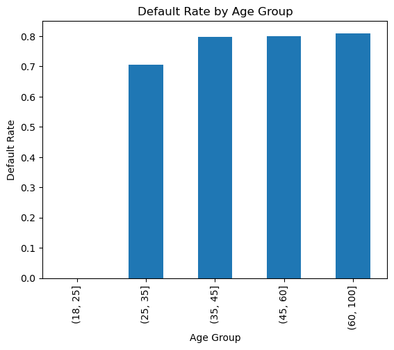

```python
#Plot of age by default,age is continous so we group into ranges

import pandas as pd
import matplotlib.pyplot as plt

data ['age_group'] = pd.cut(data['age'], bins=[18,25,35,45,60,100])

age_default = data.groupby('age_group')['default'].mean()

age_default.plot(kind='bar')
plt.title('Default Rate by Age Group')
plt.ylabel('Default Rate')
plt.xlabel('Age Group')
plt.show()
```

```python
import warnings
warnings.filterwarnings('ignore')
```

INSIGHTS FROM THE ABOVE BAR CHARTS OF AGE GROUP VERSUS DEFALUT RATE (GOOD OR BAD)

```python
#to check for minimum age in the dataset
data['age'].describe()
```

```
count    3277.000000
mean       41.284101
std         6.155209
min        30.000000
25%        37.000000
50%        41.000000
75%        45.000000
max        64.000000
Name: age, dtype: float64
```

PLOT OF DEFAULT RATE BY EDUCATION

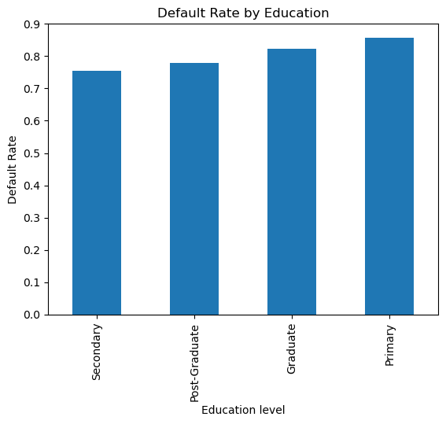

```python
edu_default = data.groupby('level_of_education_clients')['default'].mean().sort_values()

edu_default.plot(kind='bar')
plt.title('Default Rate by Education')
plt.ylabel('Default Rate')
plt.xlabel('Education level')
plt.show()
```

Insights from the above chart

This indicates: Education alone is not a strong differentiator of default risk in your dataset.

```python
print(data.columns)
```

```
Index(['customerid', 'systemloanid', 'loannumber', 'approveddate',
       'creationdate', 'loanamount', 'totaldue', 'termdays', 'referredby',
       'good_bad_flag', 'birthdate', 'bank_account_type', 'longitude_gps',
       'latitude_gps', 'bank_name_clients', 'bank_branch_clients',
       'employment_status_clients', 'level_of_education_clients', 'age',
       'num_prev_loans_x', 'avg_prev_loan_amount_x',
       'avg_days_to_first_payment_x', 'age_group', 'num_prev_loans_y',
       'avg_prev_loan_amount_y', 'avg_days_to_first_payment_y', 'default'],
      dtype='object')
```

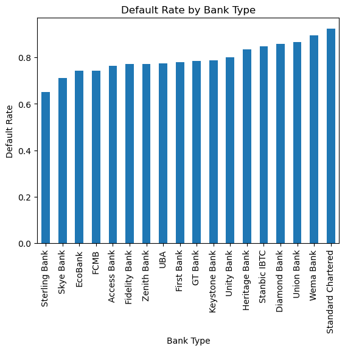

```python
#PLOT OF DEFAULT RATE BY BANK TYPE

bank_default = data.groupby('bank_name_clients')['default'].mean().sort_values()

bank_default.plot(kind='bar')
plt.title('Default Rate by Bank Type')
plt.ylabel('Default Rate')
plt.xlabel('Bank Type')
plt.show()
```

INSIGHTS FROM THE ABOVE CHART

Middle Tier Stability: A large cluster of banks (from EcoBank to Keystone Bank) shows relatively stable and similar default rates, hovering just under 0.80.

Top Tier Concentration: The final five banks on the right (Stanbic IBTC, Diamond Bank, Union Bank, Wema Bank, and Standard Chartered) show a more aggressive increase in default rates compared to the rest of the group.

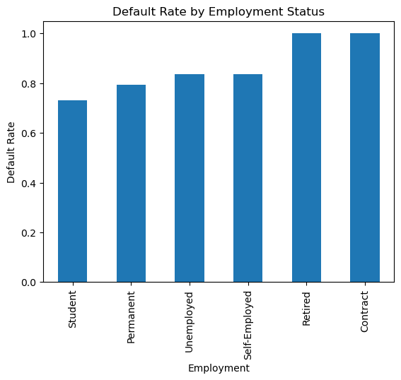

```python
#PLOT OF DEFAULT RATE BY EMPLOYMENT

emp_default = data.groupby('employment_status_clients')['default'].mean().sort_values()

emp_default.plot(kind='bar')
plt.title('Default Rate by Employment Status')
plt.ylabel('Default Rate')
plt.xlabel('Employment')
plt.show()
```

INSIGHTS FROM THE ABOVE CHART

```python
CHECKING CORRELATION BETWEEN PREVIOUS DEFAULTS AND CURRENT LOAN PERFORMANCE
```

```python
import pandas as pd


pd.crosstab(data['default'], data['good_bad_flag'], normalize='index')
```

| good_bad_flag default | Bad | Good |
| --- | --- | --- |
| 0 | 1.0 | 0.0 |
| 1 | 0.0 | 1.0 |

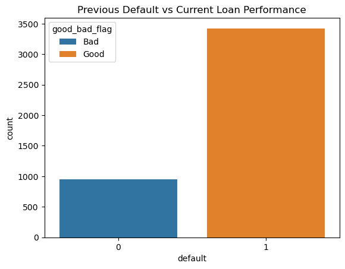

```python
import seaborn as sns
import matplotlib.pyplot as plt

sns.countplot(data=data, x='default', hue='good_bad_flag')
plt.title("Previous Default vs Current Loan Performance")
plt.show()
```

```python
from scipy.stats import chi2_contingency

table = pd.crosstab(data['default'], data['good_bad_flag'])

chi2, p, dof, expected = chi2_contingency(table)

print("Chi-square:", chi2)
print("p-value:", p)
```

```
Chi-square: 4370.131742596552
p-value: 0.0
```

. p-value = 0.0

The p-value is extremely small (almost zero) It is far below 0.05 significance level, So we reject the null hypothesis.

Null hypothesis (H₀):

Business Insight (Credit Risk Meaning)

Identifying high-risk customer clusters

```python
data['risk'] = data['good_bad_flag'].map({'Good':1, 'Bad':0})
```

```python
#creating clustering feature

features = data[['default', 'age', 'loanamount', 'employment_status_clients']]
```

```python
#if categorical,

features = pd.get_dummies(features, drop_first=True)
```

```python
#standardizing the data

from sklearn.preprocessing import StandardScaler

scaler = StandardScaler()
scaled_features = scaler.fit_transform(features)
```

```python
data.isnull().sum()
```

```
customerid                        0
systemloanid                      0
loannumber                        0
approveddate                      0
creationdate                      0
loanamount                        0
totaldue                          0
termdays                          0
referredby                     3787
good_bad_flag                     0
birthdate                      1099
bank_account_type              1099
longitude_gps                  1099
latitude_gps                   1099
bank_name_clients              1099
bank_branch_clients            4343
employment_status_clients      1592
level_of_education_clients     3933
age                            1099
num_prev_loans_x                  9
avg_prev_loan_amount_x            9
avg_days_to_first_payment_x       9
age_group                      1099
num_prev_loans_y                  9
avg_prev_loan_amount_y            9
avg_days_to_first_payment_y       9
default                           0
risk                              0
dtype: int64
```

```python
#to drop missing values

data_clean = data.dropna()
```

```python
from sklearn.pipeline import Pipeline
from sklearn.impute import SimpleImputer
from sklearn.preprocessing import StandardScaler
from sklearn.cluster import KMeans

pipeline = Pipeline([
    ('imputer', SimpleImputer(strategy='median')),
    ('scaler', StandardScaler()),
    ('kmeans', KMeans(n_clusters=4, random_state=42))
])

data['cluster'] = pipeline.fit_predict(data[['age','loanamount','avg_prev_loan_amount_x', 'totaldue', 'num_prev_loans_x' ]])
```

```python
#calculating risk per cluster

risk_by_cluster = data.groupby('cluster')['default'].mean().sort_values(ascending=False)
print(risk_by_cluster)
```

```
cluster
1    0.861472
0    0.845133
2    0.778267
3    0.743237
Name: default, dtype: float64
```

Interpretation Cluster 1 → Best quality segment Highest proportion of reliable customers Strongest candidates for lending

Cluster 0 → Very good segment Slightly below Cluster 1 but still high quality

Cluster 2 → moderate quality Mixed behavior (some risk present)

Cluster 3 → Lowest quality Highest concentration of “bad” customers Riskiest segment among the four

Business Insight (Credit Risk Strategy) Cluster Quality Level Suggested Action 1 (Excellent) Approve easily,offer better terms 0 Very Good Approve with standard terms 2 Moderate Apply stricter checks / pricing 3 Low Quality High caution / possible rejection

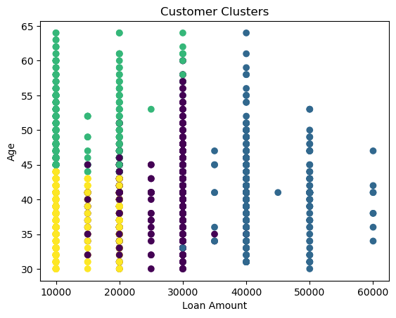

```python
#visualizing the clusters OF AGE BY LOAN AMOUNT

import matplotlib.pyplot as plt

plt.scatter(data['loanamount'],  data['age'], c=data['cluster'])
plt.xlabel("Loan Amount")
plt.ylabel("Age")
plt.title("Customer Clusters")
plt.show()
```

Insights from the above cluster

1. The "Big Borrowers" (Blue Cluster)Characteristics: This group represents the highest loan amounts, ranging from 40,000 to 60,000. Demographics: Includes a wide age range (30 to 65), suggesting that high-value loans aren't strictly tied to older, more established customers.
2. The "Senior Low-Borrowers" (Green Cluster)Characteristics: This group takes out smaller loans, primarily between 10,000 and 30,000. Demographics: Exclusively older customers, generally aged 45 to 65. This segment might prioritize smaller personal loans or have less need for large capital.
3. The "Young Entry-Level" (Yellow Cluster)Characteristics: These customers stick to the lowest loan tier, mostly at 10,000 to 20,000. Demographics: Exclusively younger customers, generally aged 30 to 45. This likely represents first-time borrowers or those with lower credit limits.
4. The "Middle-Age Mid-Borrowers" (Purple Cluster)Characteristics: These customers take mid-range loans between 20,000 and 35,000. Demographics: Primarily aged 30 to 58, but they overlap significantly with the yellow and green clusters. This group represents a transitional phase between low and high borrowing.

```python
num_cols = data.select_dtypes(include=['int64', 'float64']).columns.tolist()

# remove cluster + target column
num_cols = [col for col in num_cols if col not in ['cluster', 'good_bad_flag']]

cluster_profile_num = data.groupby('cluster')[num_cols].mean()

print(cluster_profile_num)
```

```
         systemloanid  loannumber    loanamount      totaldue   termdays  \
cluster
0        3.019797e+08    8.121681  26034.292035  30831.582190  33.667035
1        3.019806e+08   12.145022  41093.073593  46371.429437  43.928571
2        3.019817e+08    3.428781  12723.935389  15728.340675  26.718062
3        3.019813e+08    3.148562  11474.881924  14166.970803  25.395019

         longitude_gps  latitude_gps        age  num_prev_loans_x  \
cluster
0             4.354908      7.196520  40.865044          7.115044
1             4.868555      7.379832  41.049784         11.129870
2             4.702339      7.171694  49.306902          2.425406
3             4.463318      7.364713  39.013310          2.145869

         avg_prev_loan_amount_x  avg_days_to_first_payment_x  \
cluster
0                  16003.543593                    21.381389
1                  23887.866671                    23.259339
2                  10571.879909                    22.741569
3                  10198.903840                    22.349211

         num_prev_loans_y  avg_prev_loan_amount_y  \
cluster
0                7.115044            16003.543593
1               11.129870            23887.866671
2                2.425406            10571.879909
3                2.145869            10198.903840

         avg_days_to_first_payment_y   default      risk
cluster
0                          21.381389  0.845133  0.845133
1                          23.259339  0.861472  0.861472
2                          22.741569  0.778267  0.778267
3                          22.349211  0.743237  0.743237
```

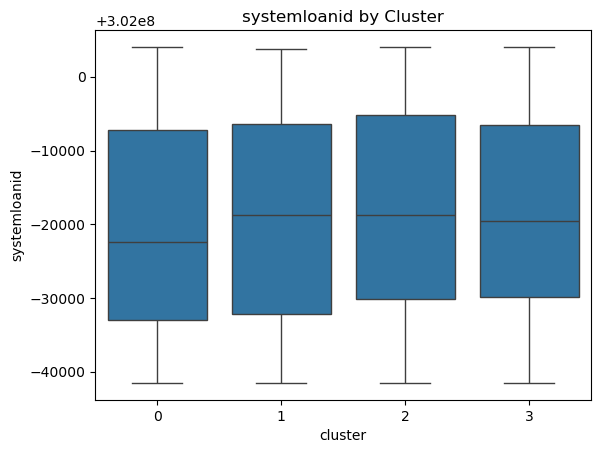

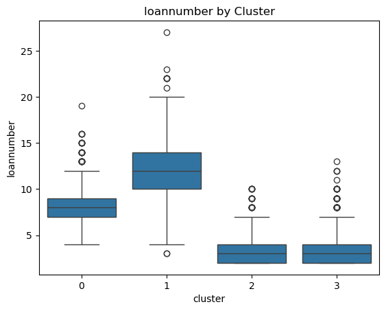

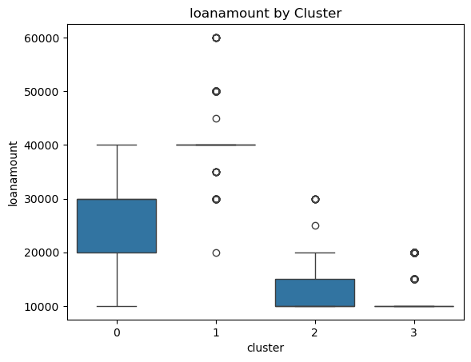

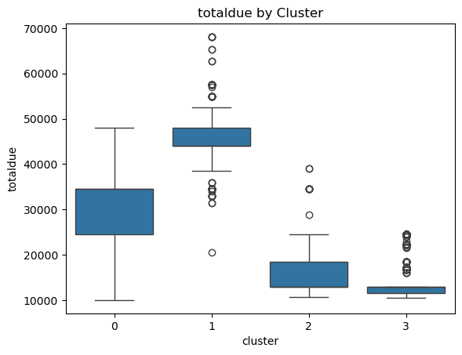

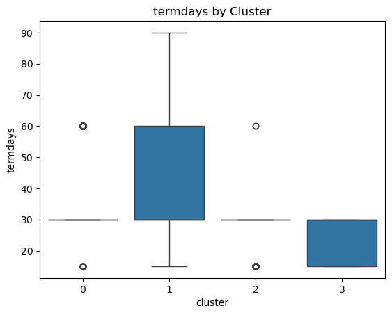

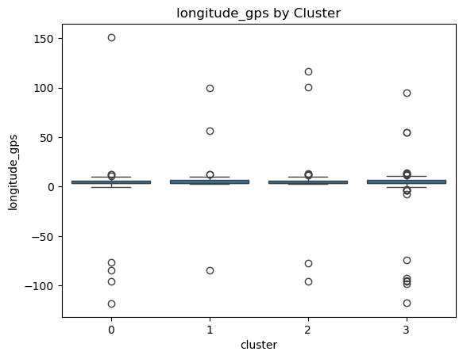

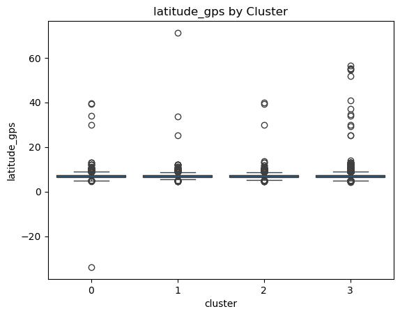

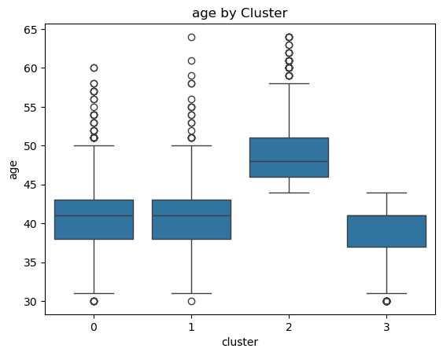

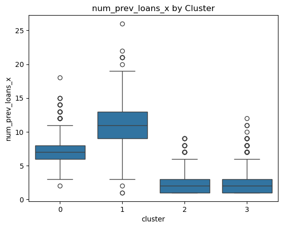

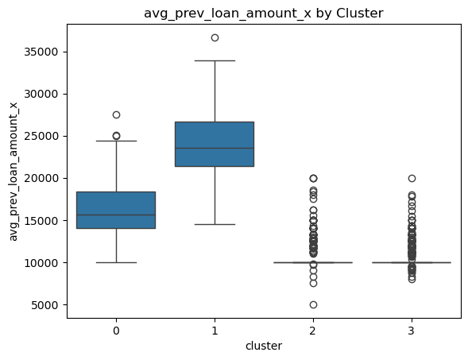

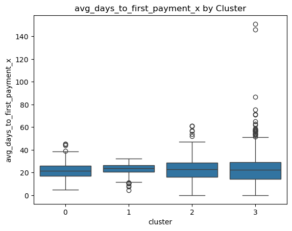

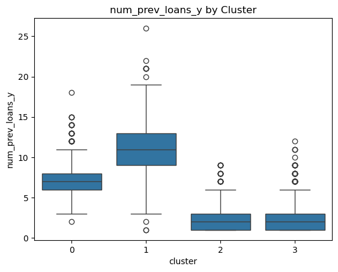

[4 more figures not shown]

```python
#showing visualization for each numerical column
import seaborn as sns
import matplotlib.pyplot as plt

for col in num_cols:
    plt.figure()
    sns.boxplot(x='cluster', y=col, data=data)
    plt.title(f'{col} by Cluster')
    plt.show()
```

The boxplot of loan amount per cluster shows how loan amounts are distributed across the four customer clusters. Each cluster represents a different borrower segment with distinct borrowing patterns.

Key Insights by Cluster Cluster 0 — Medium to High Loan Borrowers Loan amounts range roughly from 10,000 to 40,000. Median loan amount is around 20,000–30,000. The cluster has a wide spread, indicating borrowers take varying loan sizes. No major extreme outliers are visible.

This cluster contains: regular borrowers, moderate-to-high spending customers, customers with relatively stable borrowing behavior.

Business Insight These customers may represent: Medium-risk borrowers, Customers eligible for moderate credit expansion.

Cluster 1 — High-Value Borrowers Most loans are concentrated around 40,000. Several large outliers appear between 45,000 and 60,000. The cluster has the highest loan values overall.

This cluster represents: premium borrowers, customers with higher credit access, possibly long-term or trusted customers.

Business Insight Potentially profitable customer segment. May require closer risk monitoring because larger loans increase exposure. Suitable for premium lending products.

Cluster 2 — Low to Medium Loan Borrowers Most loans fall between 10,000 and 15,000. Some moderate outliers reach 20,000–30,000. Loan sizes are smaller and more controlled.

This cluster includes:

cautious borrowers, lower-income customers, new borrowers with smaller credit limits.

Business Insight Lower financial exposure and lower lending risk. Opportunity for gradual credit growth programs.

Cluster 3 — Very Small Loan Borrowers Loan amounts are tightly concentrated around 10,000. Few outliers exist around 15,000–20,000. This cluster has the smallest and most consistent loan values. Interpretation

This segment represent:

first-time borrowers, highly risk-sensitive customers, customers with limited creditworthiness.

Business Insight Lowest loan exposure. Could be targeted with financial inclusion or microcredit strategies.

Recommendations for each cluster Cluster 1: Apply stricter risk monitoring due to larger loan exposure. Cluster 0: Offer loyalty-based loan upgrades and retention programs. Cluster 2: Introduce gradual credit-building opportunities. Cluster 3: Focus on microfinance and financial inclusion products.

Loan Default Analysis Summary Report

This loan default analysis focused on identifying key factors influencing borrower repayment behavior and building a predictive model to classify borrowers as either low-risk (Good) or high-risk (Bad). The analysis explored customer demographics, financial patterns, borrower behavior, and loan characteristics to understand default trends and support data-driven lending decisions. A Random Forest classification model was developed to predict loan default outcomes and evaluate borrower risk levels.

Recommendations and Suggestions

- Financial institutions should strengthen credit checks for customers with previous default records.
- Risk-based loan pricing and monitoring strategies should be implemented for high-risk borrower groups.
- Additional customer behavioral and transactional data should be collected to improve prediction accuracy.
- Regular retraining and monitoring of the machine learning model should be carried out to maintain performance over time.
- More advanced machine learning techniques such as XGBoost, LightGBM, or ensemble models can be explored for better predictive performance.
- Financial literacy and repayment education programs may help reduce default rates among vulnerable borrower groups.
- Institutions should incorporate borrower segmentation into lending strategies for more personalized risk assessment.
- Continuous data balancing and feature engineering should be applied to improve minority class prediction.

Limitations of the Analysis

- The dataset experienced class imbalance, which initially reduced the model’s ability to predict default cases accurately.
- Some important financial variables that could improve prediction performance may have been unavailable in the dataset.
- The analysis depended heavily on historical borrower data, which may not fully capture future economic or behavioral changes.
- The model may experience overfitting if not properly validated on unseen real-world data.
- External economic factors such as inflation, unemployment, or policy changes were not included in the analysis.
- The analysis used a limited set of machine learning techniques and may benefit from comparison with additional algorithms.
- Model performance may vary when applied to different populations or financial institutions.